# Neural Network: Recognizing Student Handwriting

This is the writeup for my image classifier. This project has two goals: to create a neural network for Kaggle’s Digit Recognizer competition and to use the neural network to classify my own images. To train the neural network I will use the MNIST data set that Kaggle provides.

First I am going to load the MNIST data.

```r
setwd("H:/Google Drive/Stats Projects/Data Sets")
letter_train <- read.csv("MNIST_train.csv")
letter_test <- read.csv("MNIST_test.csv")
```

I am going to look at one of the images to see what the data provided produces. I choose the first image that produces a 7 in the data set to see how it is oriented.

```r
letter_train$label[7]
```

```
## [1] 7
```

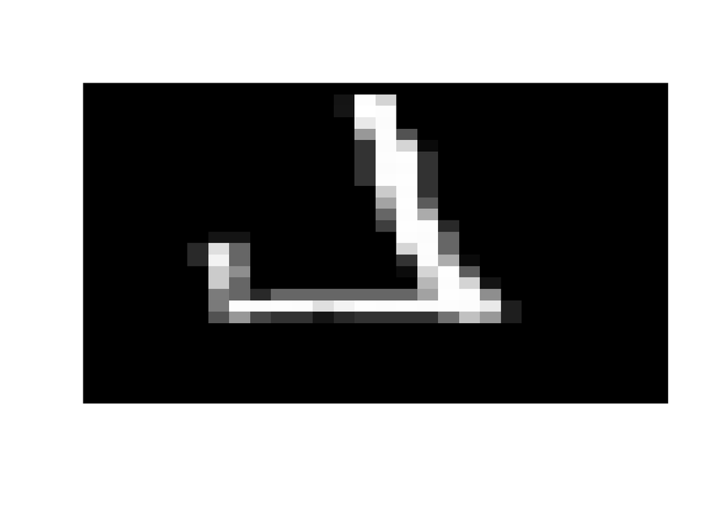

```r
Letter <- matrix(as.numeric(letter_train[7,-1]), ncol = 28, byrow = FALSE)
image(Letter, axes = FALSE, col = grey(seq(0,1,length=256)))
```

I can see that the image is not oriented correctly. The image is upside-down so I need to adjust the matrix in the image function. I reverse the order of the columns in the matrix.

[figure not shown]

```r
Letter <- matrix(as.numeric(letter_train[7,-1]), ncol = 28, byrow = FALSE)
image(Letter[, 28:1], axes = FALSE, col = grey(seq(0,1,length=256)))
```

I want to check one more image to make sure the orientation is correct.

```r
letter_train$label[22]
```

```
## [1] 6
```

[figure not shown]

```r
Letter <- matrix(as.numeric(letter_train[22,-1]), ncol = 28, byrow = FALSE)
image(Letter[, 28:1], axes = FALSE, col = grey(seq(0,1,length=256)))
```

Next I want to take a look at one of my own images. I wrote down the digits 0 through 9 on a piece of paper and took pictures of them with my cell phone. This is my number 4.

```r
library(imager)
```

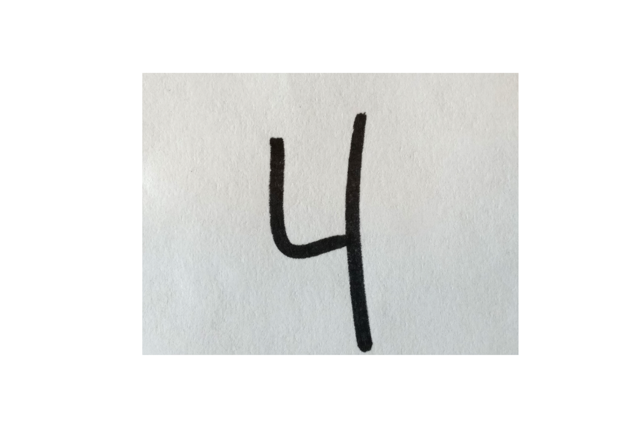

```r
setwd("H:/Google Drive/Stats Projects/Data Sets/NumberData")
Alex4 <- load.image('Alex4.png')
plot(Alex4, axes = FALSE)
```

We can see that my image does not compare well to the training set images. First, my image is in color. I use the ‘grayscale’ function to put my image in black and white. Another issue is that my image is in a much higher resolution. The MNIST data set provides 28x28 images. I resize my image accordingly. Additionally, the MNIST has white digits on a black background. I have a black digit on a white background. I will invert the colors.

```r
Alex4 <- grayscale(Alex4)         #grayscale the image
Alex4 <- resize(Alex4, 28, 28)    #resize image to 28x28
max(Alex4)                        #I need to find the darkest and lightest pixels
```

```
## [1] 0.756
```

```r
min(Alex4)
```

```
## [1] 0.08984314
```

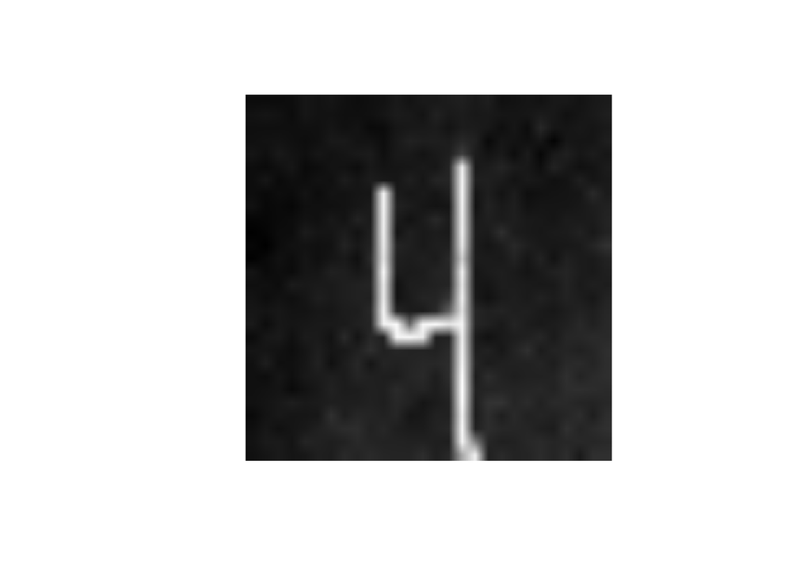

```r
Alex4 <- 1 - Alex4                #since the pixels appear to be scaled from 0 to 1, this will invert the colors.
plot(Alex4, axes = FALSE)
```

One last issue. The background is not black the way the MNIST data is. The dark pixels in my image are closer to 0, while the light pixels are closer to 1. Any pixel that has a value less than .4 I am going to completely darken with a value of 0.

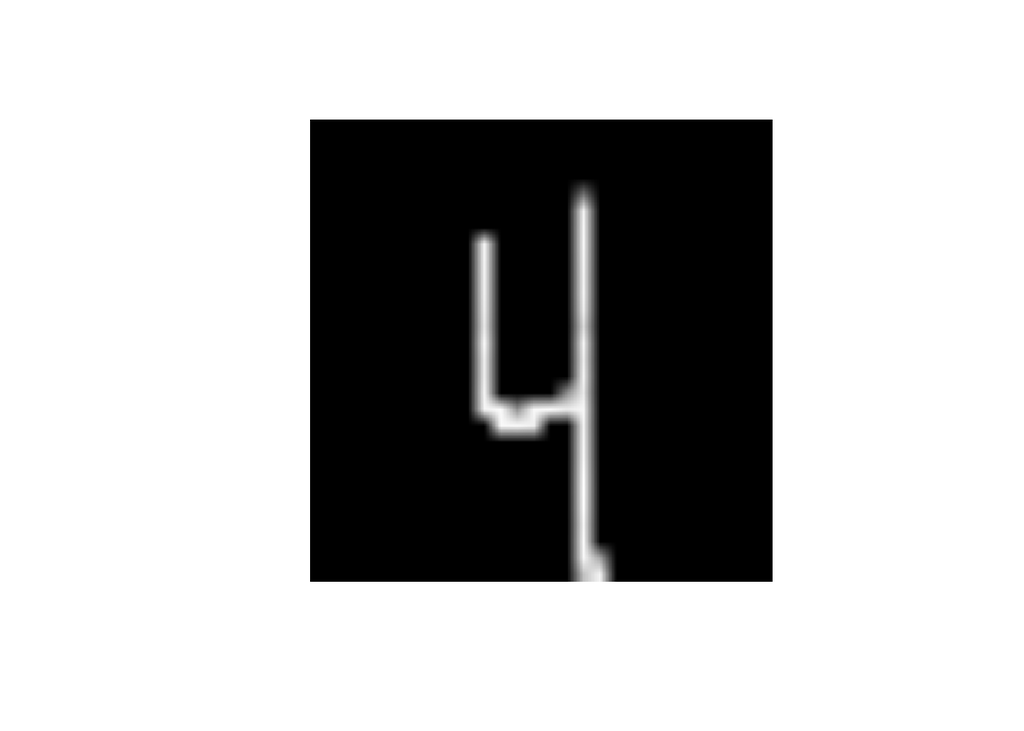

```r
for(i in 1:28){
  for(j in 1:28){
    if(Alex4[i,j,1,1] < .4){
      Alex4[i,j,1,1] <- 0
    }
  }
}
plot(Alex4, axes = FALSE)
```

The image still looks different because I am using the ‘plot’ function rather than the ‘image’ function. Let’s see that they are the same style by showing my 4 with the image function.

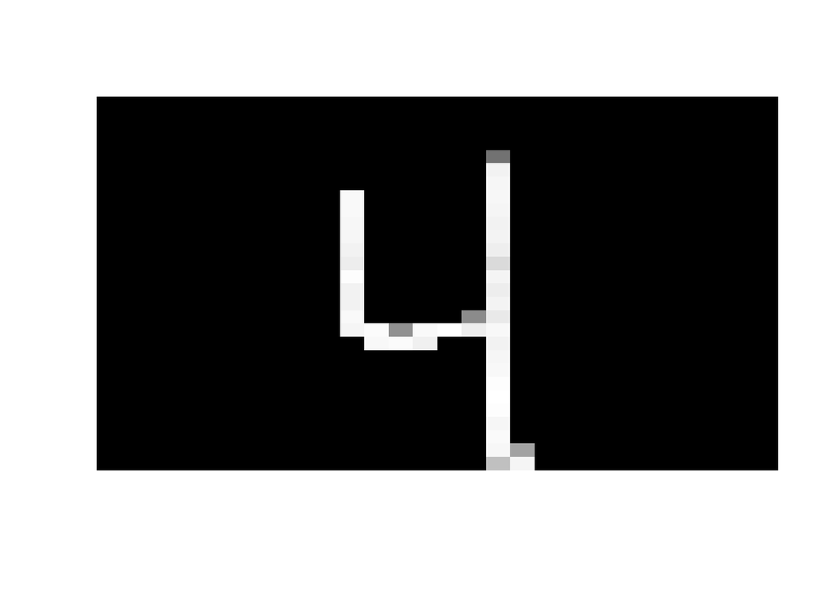

```r
Alex4_image <- c()
for(i in 1:28){
  for(j in 1:28){
    Alex4_image <- c(Alex4_image, Alex4[j,i,1,1])
  }
}
Alex4_image <- matrix(Alex4_image, ncol = 28, byrow = FALSE)
image(Alex4_image[,28:1], axes = FALSE, col = grey(seq(0,1,length=256)))
```

Before I create the neural network to classify the digits, I must pre-process the data so that it is in the same format as my image above. I need to darken the background by reducing the pixel number to 0 and make sure that the smallest and largest pixel values are 0 and 1. First I create a table that shows the numeric values for pixel 400. Since the pixels can be numbered from 0 to 255, I only show the first few rows of the table.

```r
head(table(letter_train$pixel400))
```

```
##
##     0     1     2     3     4     5
## 24771    41    38    51    67    52
```

I see that most of the pixels are completely black, there are 24,771 pixels with a value of 0. However there are 41 pixels with a value of 1, and many pixels with a value of 2, 3, 4, and 5. These are close enough to completely black that I want to darken them completely. I darken the background by setting all pixel values less than 102 to 0, since .4*255 = 102. Next, I normalize the values by dividing by the maximum value of 255. I do this for the training and testing set.

```r
for(i in 2:785){
  letter_train[which(letter_train[,i] < 102),i] <- 0
  letter_train[,i] <- letter_train[,i]/255
}

for(i in 1:784){
  letter_test[which(letter_test[,i] < 102),i] <- 0
  letter_test[,i] <- letter_test[,i]/255
}
```

I want to reduce the amount of training data that I feed to the neural network. To do this I remove all columns of data that show little variation. This will speed up the training of the neural network. I use the ‘nearZeroVar’ function to determine the columns that have little variance.

```r
library(caret)
```

```r
novar <- nearZeroVar(letter_train)
novar_label <- novar - 1

length(novar)   #show how many pixels are omitted out of 784
```

```
## [1] 542
```

```r
letter_train <- letter_train[,-novar]
letter_test <- letter_test[,-novar_label]
```

Let’s see if there is a reasonable pattern to which pixels have been omitted. The black pixels are excluded below, the white pixels are used in the neural network training.

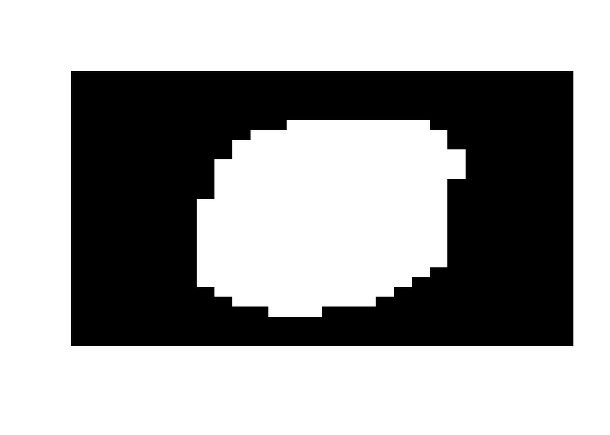

```r
excluded <- rep(1, 784)                #Create a vector of 784 pixels each set to 1 (white)
for(i in 1:length(novar_label)){       #This loop fills in the pixels that are black
  excluded[novar_label[i]] <- 0
}

excluded <- matrix(as.numeric(excluded), ncol = 28, byrow = FALSE)
image(excluded[, 28:1], axes = FALSE, col = grey(seq(0,1,length=256))) #Show excluded pixels
```

I can see that all the omitted pixels are around the border of the image.

For the ‘neuralnet’ package in R, it is best to expand out the dependent variable, ‘label’. Rather than have one column that indicates what the handwritten digit is there will be ten columns, one for each digit.

```r
letter_train$label0 <- 0    #I start by creating ten columns and filling the with zeros
letter_train$label1 <- 0
letter_train$label2 <- 0
letter_train$label3 <- 0
letter_train$label4 <- 0
letter_train$label5 <- 0
letter_train$label6 <- 0
letter_train$label7 <- 0
letter_train$label8 <- 0
letter_train$label9 <- 0

letter_train$label0[which(letter_train$label == 0)] <- 1  #If the label column indicated a zero, set label0 equal to one
letter_train$label1[which(letter_train$label == 1)] <- 1
letter_train$label2[which(letter_train$label == 2)] <- 1
letter_train$label3[which(letter_train$label == 3)] <- 1
letter_train$label4[which(letter_train$label == 4)] <- 1
letter_train$label5[which(letter_train$label == 5)] <- 1
letter_train$label6[which(letter_train$label == 6)] <- 1
letter_train$label7[which(letter_train$label == 7)] <- 1
letter_train$label8[which(letter_train$label == 8)] <- 1
letter_train$label9[which(letter_train$label == 9)] <- 1

letter_train <- letter_train[,c(244:253, 2:243)] #This puts the 10 dependent variable columns up front and removes the original 'label' column

head(letter_train[,1:10]) #Notice how each row only has a 1 in one of the ten columns indicating the digit.
```

```
##   label0 label1 label2 label3 label4 label5 label6 label7 label8 label9
## 1      0      1      0      0      0      0      0      0      0      0
## 2      1      0      0      0      0      0      0      0      0      0
## 3      0      1      0      0      0      0      0      0      0      0
## 4      0      0      0      0      1      0      0      0      0      0
## 5      1      0      0      0      0      0      0      0      0      0
## 6      1      0      0      0      0      0      0      0      0      0
```

The ‘neuralnet’ package requires the input formula be written out explicitly, namely I cannot write ‘label0 + label1 + label2 + label3 + label4 + label5 + label6 + label7 + label8 + label9 ~ .’. Since I have over 200 independent variables I will set up the formula with a for loop and store it in variable ‘f’.

```r
f <- "label0 + label1 + label2 + label3 + label4 + label5 + label6 + label7 + label8 + label9 ~ pixel152"

for(i in 12:length(letter_train)){
  f <- paste(f, colnames(letter_train)[i], sep = " + ")
}
f <- as.formula(f)
```

Next I load the ‘neuralnet’ package and set up the parameters for the neural network. I set the seed to 123 so that I can get reproducible results. Since I am classifying digits I set the activation function to “logistic” for logistic regression and set linear.output to FALSE.

```r
library(neuralnet)
```

```r
set.seed(123)
nn1 <- neuralnet(f, data = letter_train, lifesign = "full",
                act.fct = "logistic", err.fct = "ce", stepmax = 5e+4, linear.output = FALSE,
                threshold = .03, hidden = 125)
```

```
## hidden: 125    thresh: 0.03    rep: 1/1    steps:    1000    min thresh: 0.1167574673
##                                                      1146    error: 2.07702  time: 49.18 mins
```

After I create the neural network, I use it to make predictions on Kaggle’s test set.

```r
nn_pred1 <- neuralnet::compute(nn1, letter_test)$net.result       #This returns a 10 column matrix that shows the probability of the image being each digit 0 through 9
predictions <- c()

for(i in 1:28000){                                               #I create a vector with the models prediction.
  predictions <- c(predictions, (which.max(nn_pred1[i,]) - 1))    #The model predicts the digit with the highest probability
}

submission <- data.frame(ImageID = c(1:28000), label = predictions)

setwd("H:/Google Drive/Stats Projects/Data Sets")                #Create submission file
write.csv(submission, "Kaggle_MNIST_Submission.csv", row.names = FALSE)
```

I submitted my predictions to Kaggle and had a 95% accuracy on the test set. This was good for the top 84%. My Kaggle profile can be seen at https://www.kaggle.com/jgarcia102.

My second goal for this project was to use the neural network to recognize student handwriting. I create a function that does two things. It displays the 28 by 28 image that the neural network sees and it predicts which digit the the student wrote down. The function I create requires two inputs: the image of student handwriting and the vector with the pixels omitted from the ‘nearZeroVar’ function. I commented on what each part of the function I wrote is doing

```r
ImagePredictor <- function(FileName, novar){
  setwd("H:/Google Drive/Stats Projects/Data Sets/NumberData")  #set the working directory where the images are
  ImageData <- load.image(FileName)                             #load the image
  ImageData <- grayscale(ImageData)                             #grayscale the image
  ImageData <- resize(ImageData, 28, 28)                        #resize the image to 28 by 28
  ImageData <- 1 - ImageData                                    #invert the colors so it is a white digit on black background

  number <- c()                                                 #Convert the pixel data to a vector of length 784
  for(i in 1:28){
    for(j in 1:28){
      number <- c(number, ImageData[i,j,1,1])
    }
  }

  number[which(number[] < .4)] <- 0                             #darken the background pixels to a value of 0

  M <- matrix(number, ncol = 28, byrow = TRUE)                  #Convert the vector to a matrix so I can display the image
  M <- M[,ncol(M):1]                                             #Rearrange the matrix to correctly orient the image
  image(M, axes = FALSE, col = grey(seq(0,1,length=256)))       #Display the image
  M <- t(M[,ncol(M):1])                                          #rearrange the matrix to later convert to a vector with the pixels in the correct order

  number <- c()                                                  #Convert to a vector
  for(i in 1:28){
    for(j in 1:28){
      number <- c(number, M[i,j])
    }
  }

  number <- number[-novar_label]                                #remove the unused pixels
  number <- matrix(number, ncol = length(number))               #create a 1 row matrix to make a prediction
  prediction <- neuralnet::compute(nn1, number)$net.result      #calculate the probabilities of the image being each digit

  print(which.max(prediction) - 1)                              #display the final prediction
}
```

I have a student named Sam who volunteered to write down the digits 0 through 9 for this website. Let’s see how well the neural network does on his handwriting.

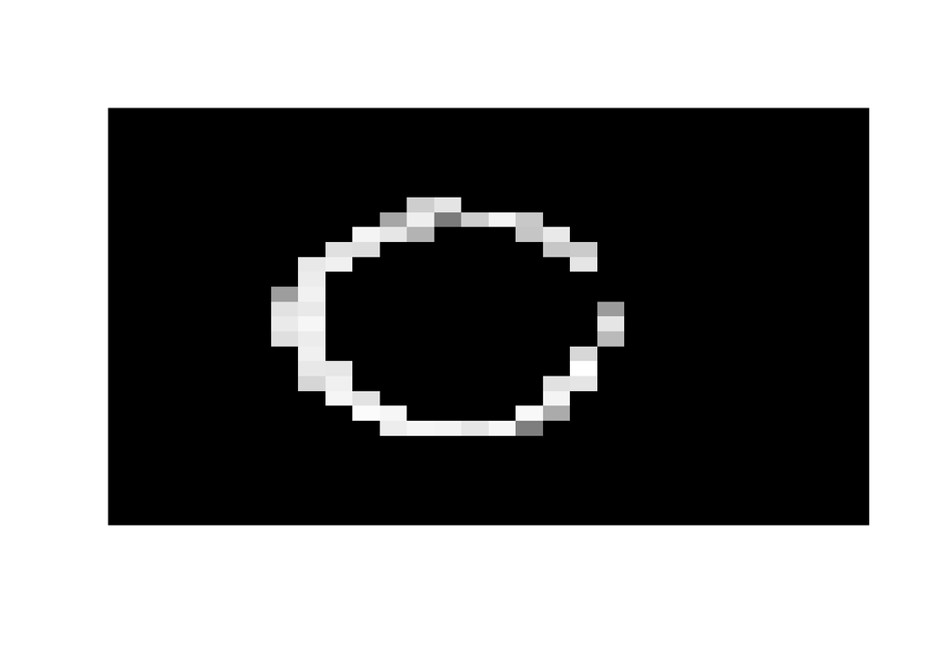

```
## [1] 0
```

```r
ImagePredictor("Sam0.png", novar_label)
```

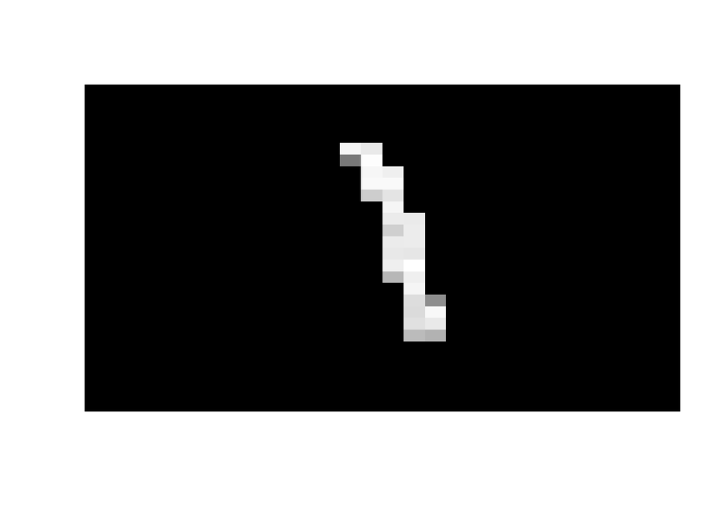

```
## [1] 1
```

```r
ImagePredictor("Sam1.png", novar_label)
```

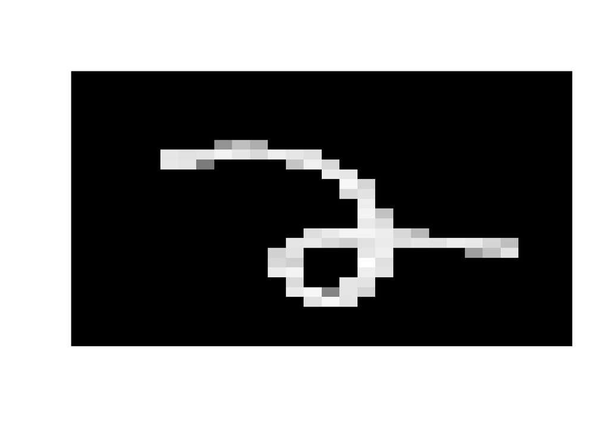

```
## [1] 2
```

```r
ImagePredictor("Sam2.png", novar_label)
```

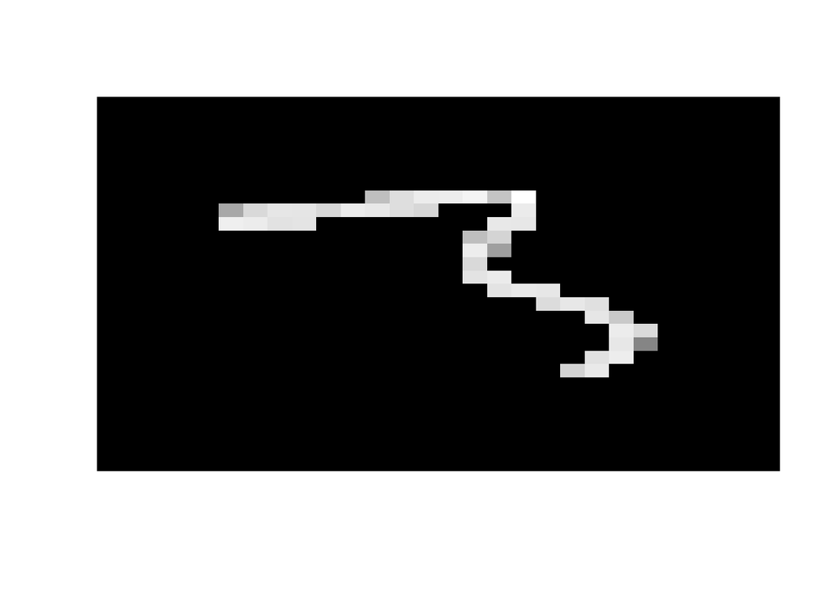

```
## [1] 3
```

```r
ImagePredictor("Sam3.png", novar_label)
```

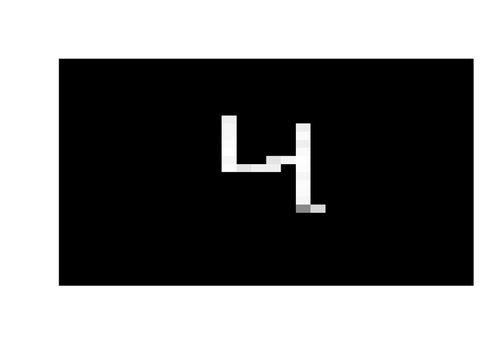

```
## [1] 4
```

```r
ImagePredictor("Sam4.png", novar_label)
```

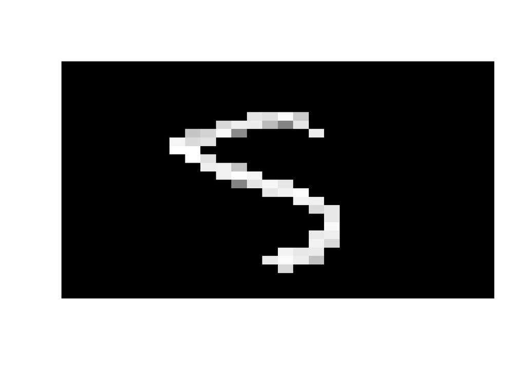

```
## [1] 5
```

```r
ImagePredictor("Sam5.png", novar_label)
```

[figure not shown]

```
## [1] 6
```

```r
ImagePredictor("Sam6.png", novar_label)
```

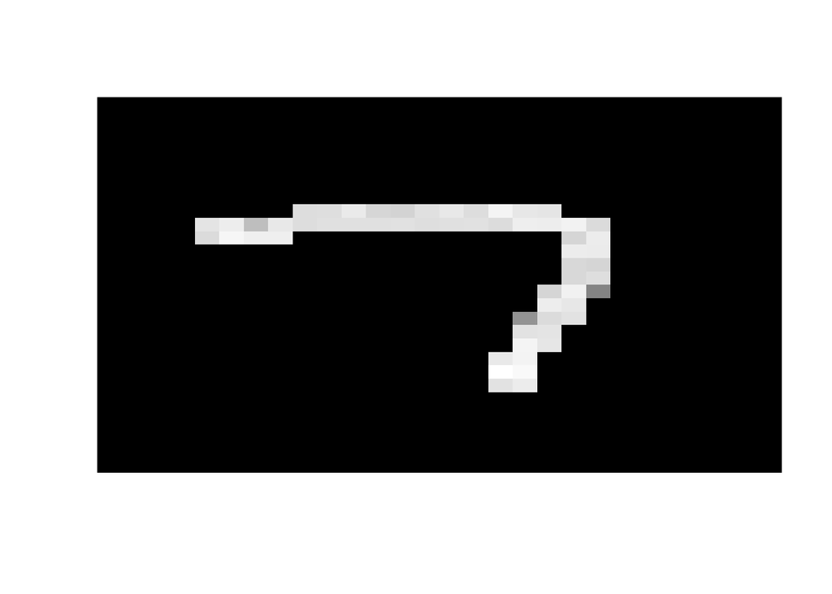

```
## [1] 7
```

```r
ImagePredictor("Sam7.png", novar_label)
```

[figure not shown]

```
## [1] 8
```

```r
ImagePredictor("Sam8.png", novar_label)
```

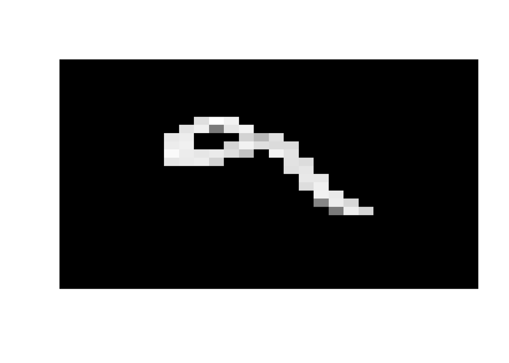

```
## [1] 7
```

```r
ImagePredictor("Sam9.png", novar_label)
```

Sam provided a challenging handwriting sample for the neural network and it was able to correctly predict 9 out of 10 of his digits!